# Module 3, Lesson 2: Collective geoms

In the second lesson of Module 3, you learned about histograms, barplots, and boxplots – all of which are “collective geoms”. Remember that collective geoms are so-called because rather than plotting individual data they plot summaries of the data. A collective geom is intended to show some overall feature of the data instead of specific data points.

Open the R project called `Lessons.Rproj` and a blank R script. Then, load the necessary packages into the current R session:

```r
library(tidyverse)
```

## `geom_histogram`

As you saw in the video, a histogram is created by first binning or grouping together observations having numeric values that are considered near to one another in some sense (more on this in a moment) and then plotting these groups as rectangles with height equal to the number of observations in a bin.

To create a histogram of the infant weights, we use the following code, mapping `weight_kg` to the `x` aesthetic:

```r
ggplot(data = growth_data) +
  geom_histogram(mapping = aes(x = weight_kg),
                 binwidth = 1)
```

[output not shown]

This geom has an extra argument that we’ve not seen before, `binwidth`, which we set equal to 1 in the call above. Note that it falls *outside* of the aesthetic mappings in the `aes` function. This choice means that the size of the bins is equal to 1. For example, the first bin starts at 2.5 and ends at 3.5, hence the width is 3.5 - 2.5 or 1. And the same goes for the rest of the bins: 4.5 - 3.5, 5.5 - 4.5, etc. Different choices of `binwidth` may give dramatically different results, particularly for small datasets like this one. Try out different values of `binwidth` to see for yourself.

```r
ggplot(data = growth_data) +
  geom_histogram(mapping = aes(x = weight_kg),
                 binwidth = 0.25)
```

```r
ggplot(data = growth_data) +
  geom_histogram(mapping = aes(x = weight_kg),
                 binwidth = 2.0)
```

You might be thinking that only choosing `binwidth` is not sufficient to determine how the histogram should appear. For example, if `binwidth` is 1, you could have a bin of (2.5, 3.5) or (2.6, 3.6) or (2.7, 3.7) or… How does `ggplot` choose (2.5, 3.5)? In fact, if you only specify `binwidth`, by default `ggplot` will anchor all bins based upon the (potentially theoretical) bin centered at 0, with boundaries equal to half of `binwidth` in either direction (I say this is “potentially theoretical” because your numbers may be much much bigger than 0). So this anchoring bin in our case is (-0.5, 0.5). Once you know this bin, all of the other bins become automatically determined, i.e. (0.5, 1.5), (1.5, 2.5), etc.

As you might be figuring out by know, you can override this default behavior by specifying `center`, as in:

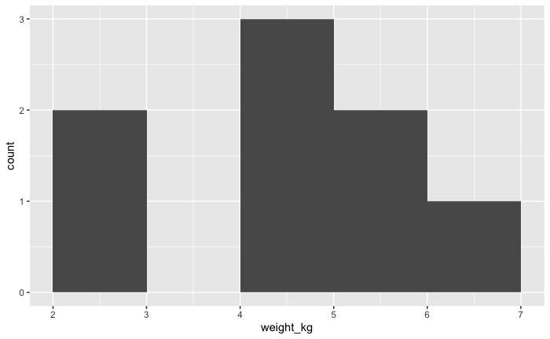

```r
ggplot(data = growth_data) +
  geom_histogram(mapping = aes(x = weight_kg),
                 binwidth = 1,
                 center = 1.5)
```

Centering the first bin at 1.5, the bins become (2, 3), (3, 4), etc. Alternatively, instead of specifying `center`, you can specify `boundary`, which gives the edge of a bin:

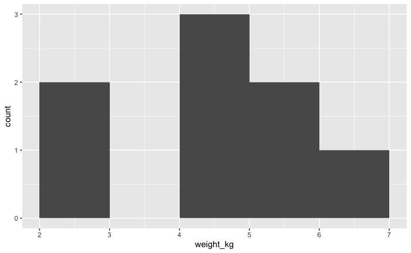

```r
ggplot(data = growth_data) +
  geom_histogram(mapping = aes(x = weight_kg),
                 binwidth = 1,
                 boundary = 1)
```

Setting `center = 0.5` gives the same result as `boundary = 1` (when `binwidth=1`).

There are opportunities to have your histogram tell a different story through your choice of `binwidth` and `center` or `boundary`. For example, consider what happens when we move the value of `center` from 1.5 above to 1.4 below:

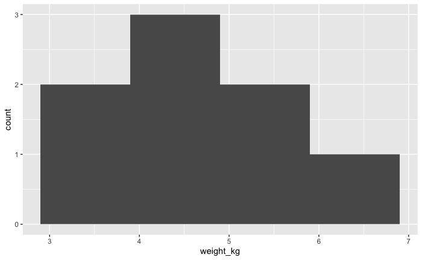

```r
ggplot(data = growth_data) +
  geom_histogram(mapping = aes(x = weight_kg),
                 binwidth = 1,
                 center = 1.4)
```

A small change in one argument results in a much different-looking histogram. Related to this, if you fail to choose `binwidth`, `ggplot` will make some default decisions, and these won’t necessarily be good decisions:

```r
ggplot(data = growth_data) +
  geom_histogram(mapping = aes(x = weight_kg))
```

[output not shown]

Your responsibility as a data scientist is to choose values that most faithfully represent your data, and this can be challenging sometimes!

Lastly, note that you can create a horizontal histogram by mapping your variable to the `y` aesthetic:

```r
ggplot(data = growth_data) +
  geom_histogram(mapping = aes(y = weight_kg),
                 binwidth = 1)
```

[output not shown]

Now, the x-axis is used to represent the counts.

Save this script as `03_02collectivegeoms.R`.